# Exercise 1: Student Performance Visualization

## Add plot title

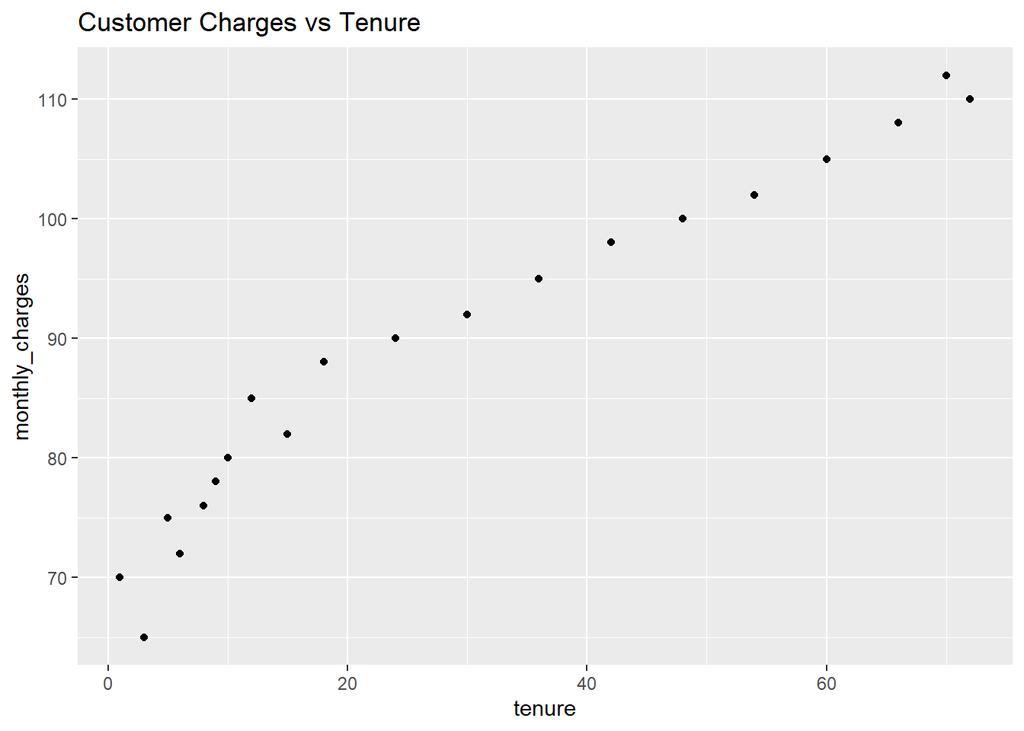

```r
ggplot(datos_churn, aes(x=tenure, y=monthly_charges)) +
  geom_point() +
  ggtitle("Customer Charges vs Tenure")
```

Se identifica visualmente la relación entre permanencia y cargos.

## Boxplot: monthly_charges by churn

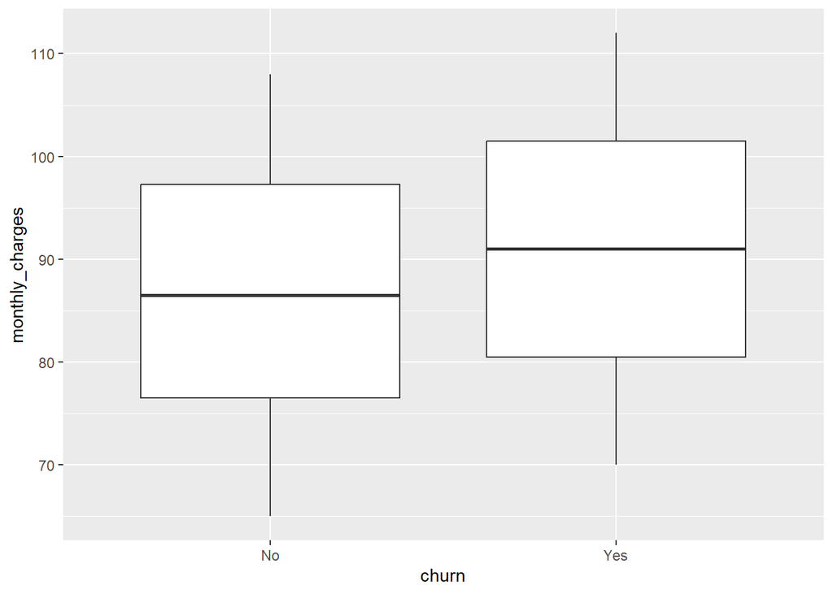

```r
ggplot(datos_churn, aes(x=churn, y=monthly_charges)) +
  geom_boxplot()
```

Los cargos mensuales presentan una distribución parecida entre ambos grupos.

## Histograma: Tenure

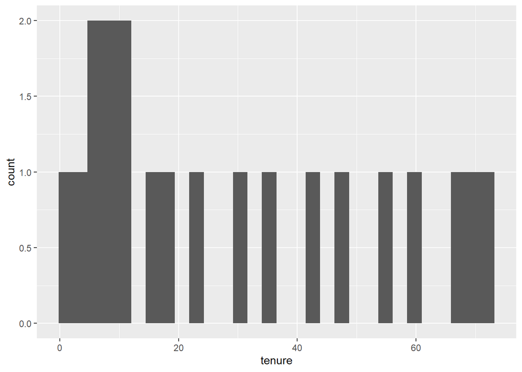

```r
ggplot(datos_churn, aes(tenure)) +
  geom_histogram()
```

La permanencia se distribuye en distintos intervalos de clientes.

## Change Histogram bins

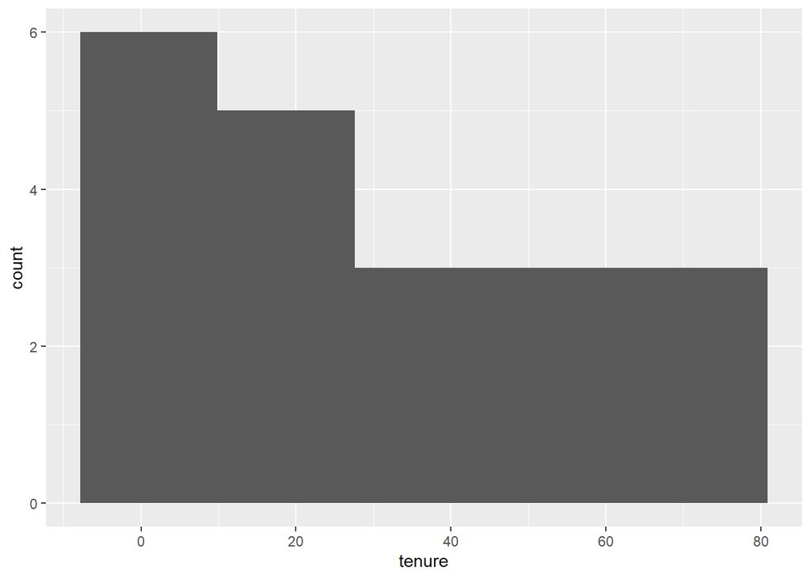

```r
ggplot(datos_churn, aes(tenure)) +
  geom_histogram(bins=5)
```

Con menos intervalos se observa una agrupación más general.

## Violin plot: monthly_charges by contract

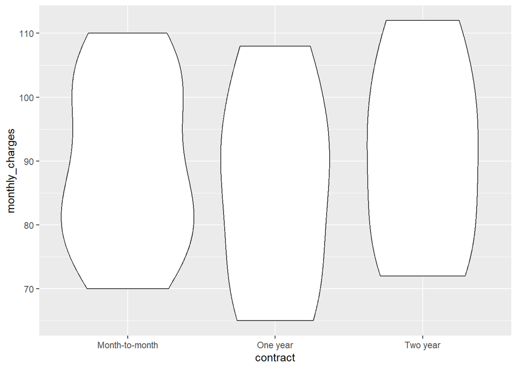

```r
ggplot(datos_churn, aes(contract, y=monthly_charges)) +
  geom_violin()
```

Cada tipo de contrato presenta distinta concentración de cargos.

## Density plot: monthly_charges colored by churn

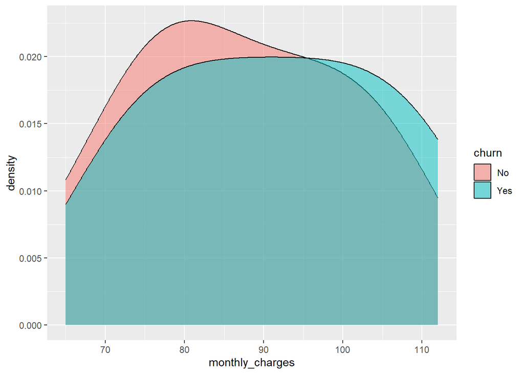

```r
ggplot(datos_churn, aes(monthly_charges, fill=churn)) +
  geom_density(alpha=0.5)
```

La densidad permite comparar cómo se distribuyen los cargos mensuales.

## Bar plot: count customers by contract

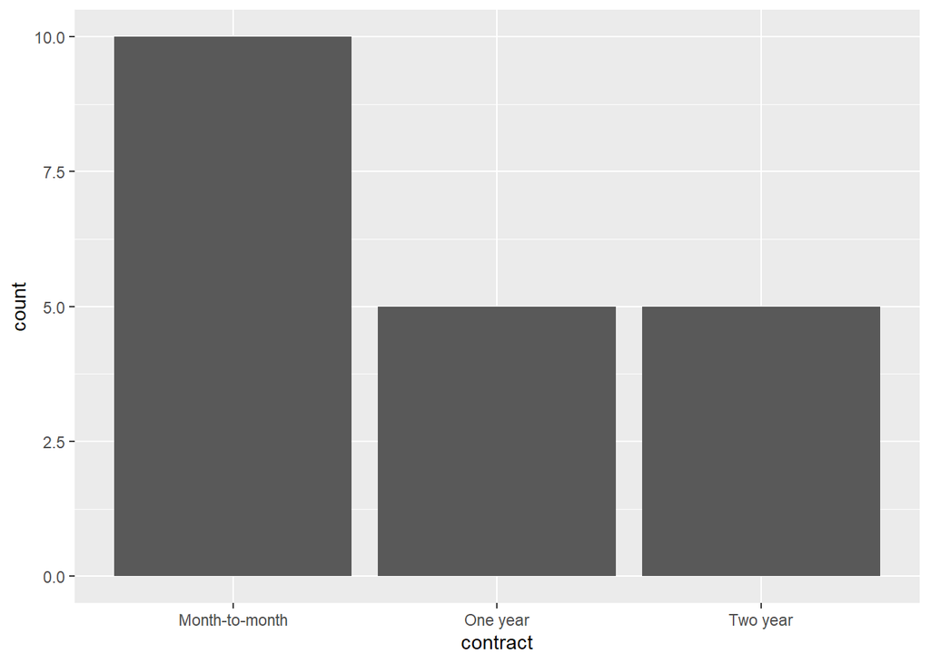

```r
ggplot(datos_churn, aes(contract)) +
  geom_bar()
```

Se observa la frecuencia de clientes por contrato.

## Bar plot filled by churn

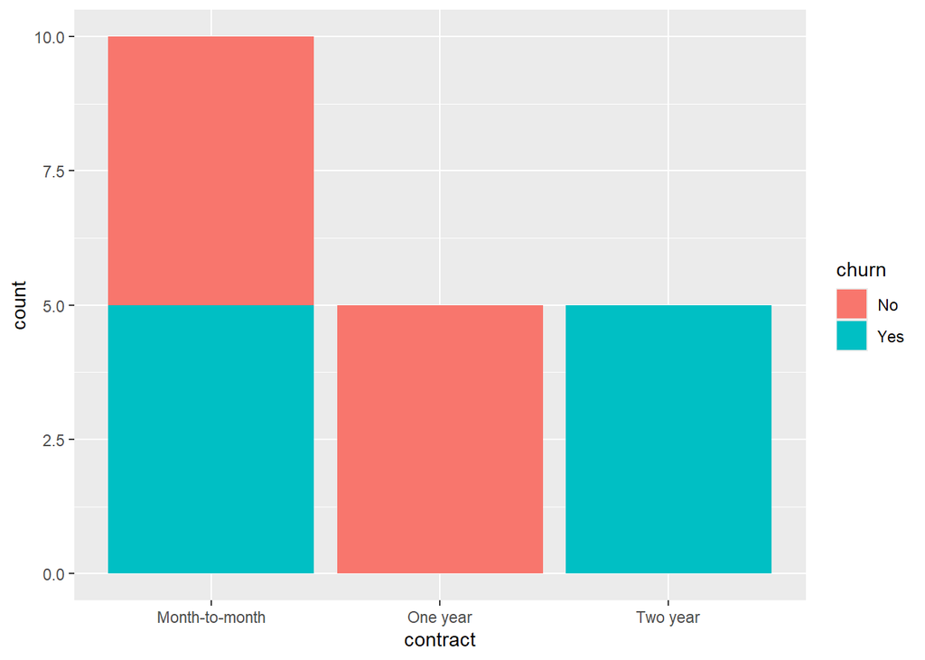

```r
ggplot(datos_churn, aes(contract, fill=churn)) +
  geom_bar()
```

Se compara churn dentro de cada contrato.

## Facet scatter plot by internet_service

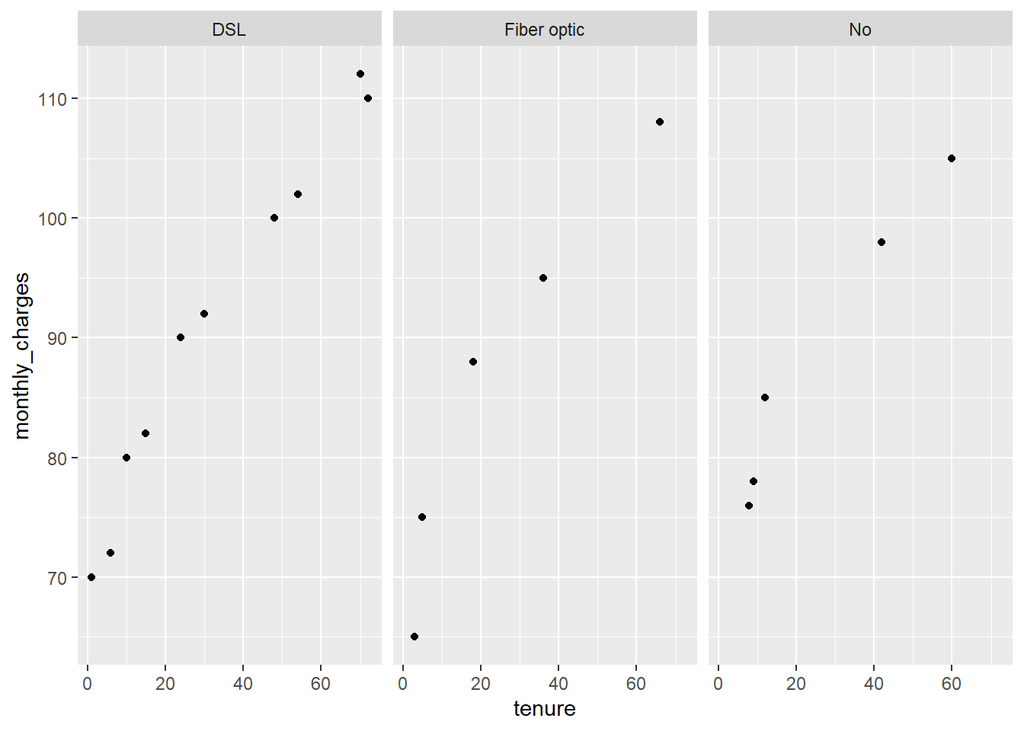

```r
ggplot(datos_churn, aes(tenure, monthly_charges)) +
  geom_point() +
  facet_wrap(~internet_service)
```

Cada servicio de internet muestra comportamientos distintos.

## Facet wrap by contract

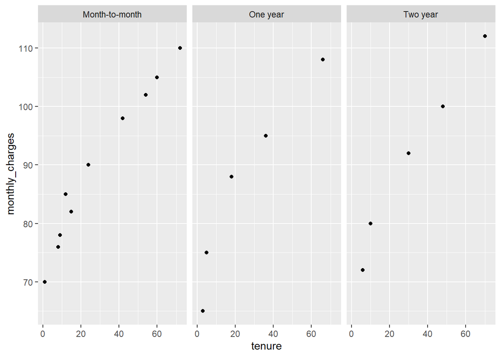

```r
ggplot(datos_churn, aes(tenure, monthly_charges)) +
  geom_point() +
  facet_wrap(~contract)
```

El comportamiento cambia según el contrato.

## Line plot: average monthly charges by tenure

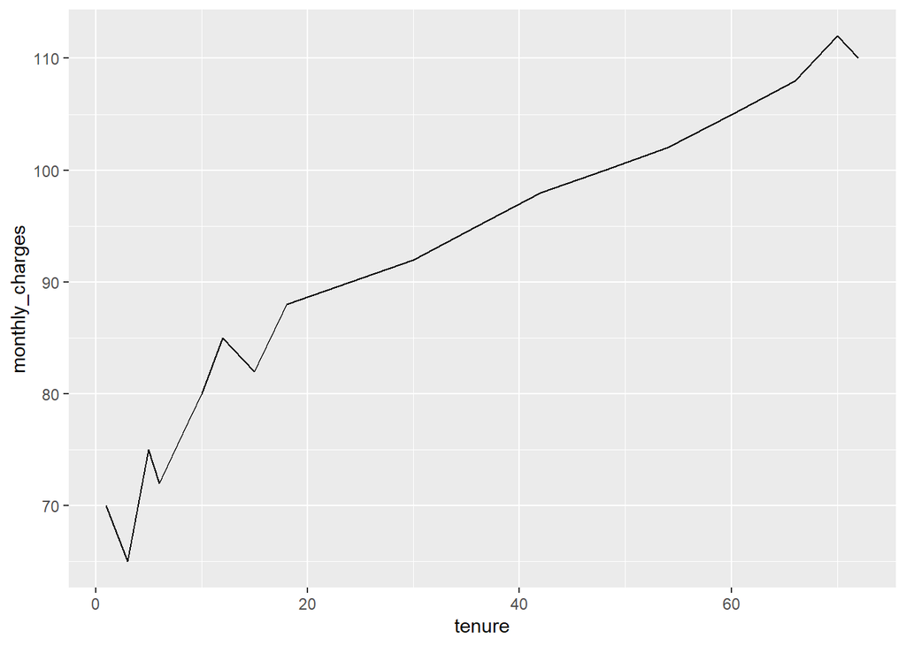

```r
ggplot(datos_churn, aes(tenure, monthly_charges)) +
  stat_summary(fun=mean, geom="line")
```

La media de cargos varía conforme aumenta la permanencia.

## Scatter plot

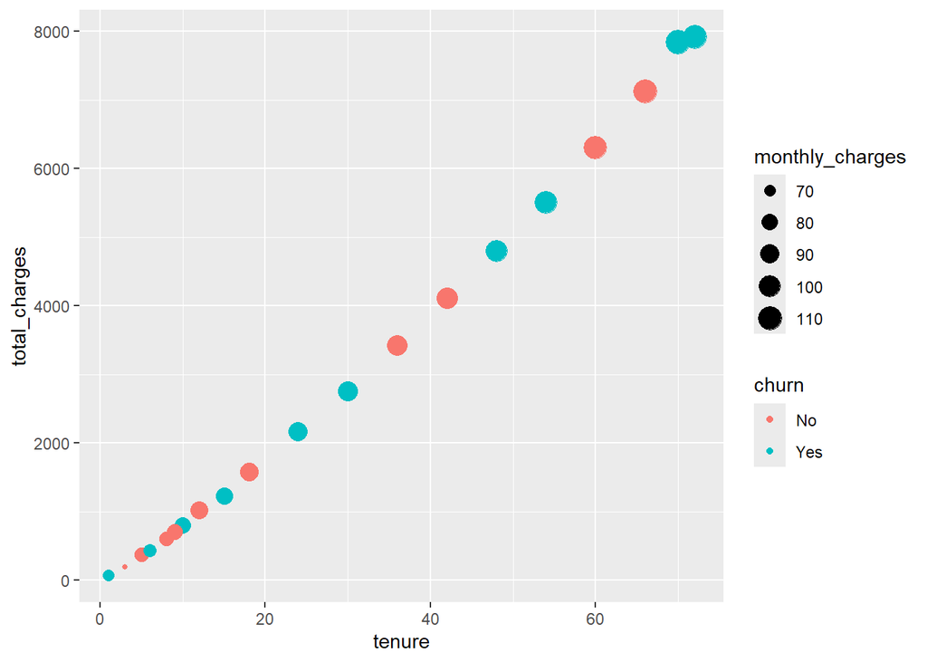

```r
ggplot(datos_churn, aes(x=tenure, y=total_charges, color=churn, size=monthly_charges)) +
  geom_point()
```

Los cargos totales aumentan con la permanencia.

## Jitter plot: tenure vs churn

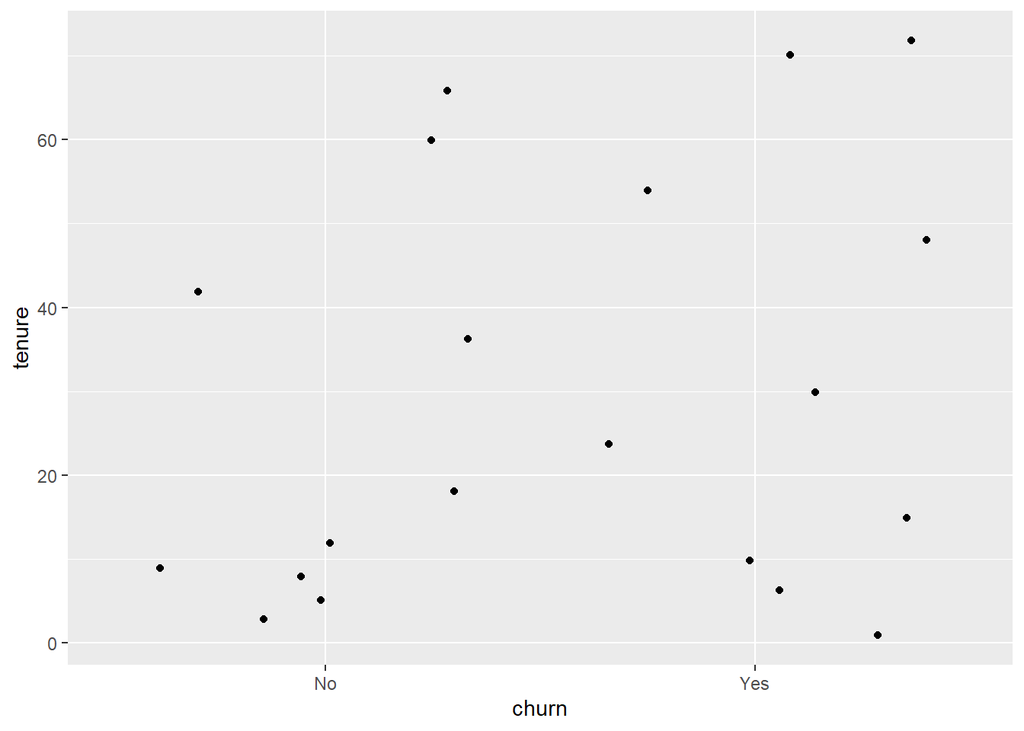

```r
ggplot(datos_churn, aes(x=churn, y=tenure)) +
  geom_jitter()
```

Se visualiza mejor la dispersión de permanencia por grupo.

## Add transparency to scatter plot

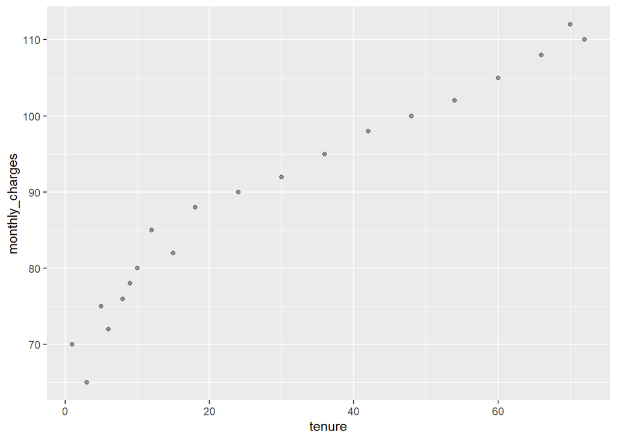

```r
ggplot(datos_churn, aes(x=tenure, y=monthly_charges)) +
  geom_point(alpha=0.4)
```

La transparencia facilita observar puntos superpuestos.

## Customize legend position

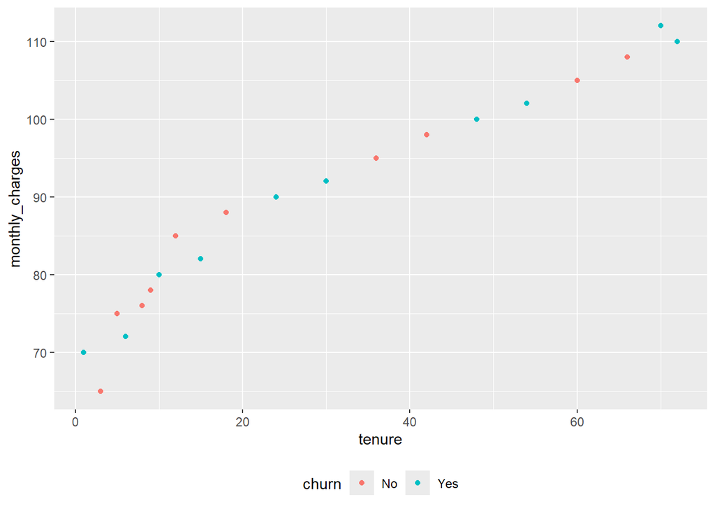

```r
ggplot(datos_churn, aes(x=tenure, y=monthly_charges, color=churn)) +
  geom_point() +
  theme(legend.position="bottom")
```

La leyenda se ubica abajo para una lectura más cómoda.

## Create publication-style visualization

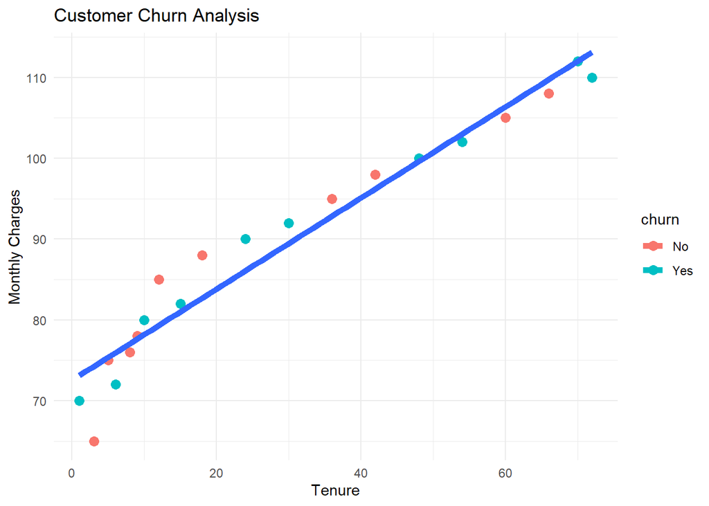

```r
ggplot(datos_churn, aes(x=tenure, y=monthly_charges, color=churn)) +
  geom_point(size=3) +
  geom_smooth(method="lm", se=FALSE, linewidth=2, aes(group=1)) +
  theme_minimal() +
  labs(
    title="Customer Churn Analysis",
    x="Tenure",
    y="Monthly Charges"
  )
```

La visualización resume la tendencia general entre permanencia y cargos mensuales.

##“Punto 4: Telco Customer Churn” Taliana Pirajan 2026-03-29 —

```r
library(readr)
library(tidyverse)
churn <- read_csv("C:/Users/Tatiana/Downloads/archive/WA_Fn-UseC_-Telco-Customer-Churn.csv")
names(churn) <- tolower(names(churn))

churn$churn <- as.factor(churn$churn)
churn$contract <- as.factor(churn$contract)
churn$internetservice <- as.factor(churn$internetservice)

head(churn)
```

```
## # A tibble: 6 × 21
##   customerid gender seniorcitizen partner dependents tenure phoneservice
##   <chr>      <chr>          <dbl> <chr>   <chr>       <dbl> <chr>
## 1 7590-VHVEG Female             0 Yes     No              1 No
## 2 5575-GNVDE Male               0 No      No             34 Yes
## 3 3668-QPYBK Male               0 No      No              2 Yes
## 4 7795-CFOCW Male               0 No      No             45 No
## 5 9237-HQITU Female             0 No      No              2 Yes
## 6 9305-CDSKC Female             0 No      No              8 Yes
## # ℹ 14 more variables: multiplelines <chr>, internetservice <fct>,
## #   onlinesecurity <chr>, onlinebackup <chr>, deviceprotection <chr>,
## #   techsupport <chr>, streamingtv <chr>, streamingmovies <chr>,
## #   contract <fct>, paperlessbilling <chr>, paymentmethod <chr>,
## #   monthlycharges <dbl>, totalcharges <dbl>, churn <fct>
```

# Plot tenure distribution

## Ternure

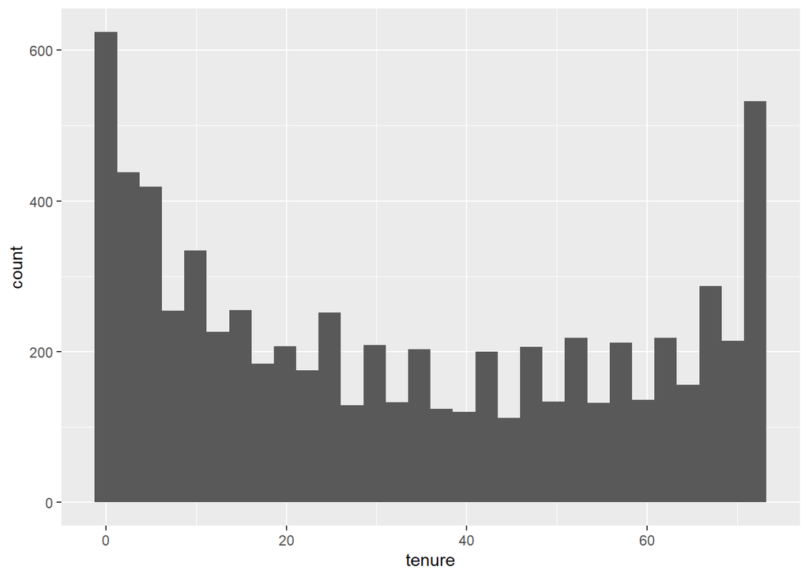

```r
ggplot(churn, aes(tenure)) +
  geom_histogram(bins = 30)
```

## Plot monthly charges distribution

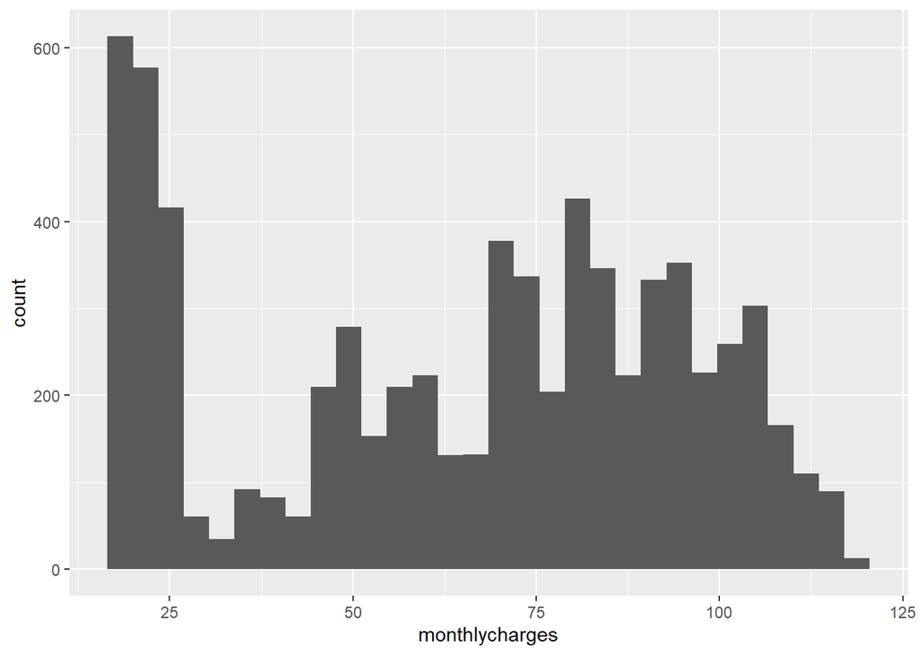

```r
ggplot(churn, aes(monthlycharges)) +
  geom_histogram(bins = 30)
```

Los cargos mensuales se distribuyen en varios rangos.

## Plot total charges distribution

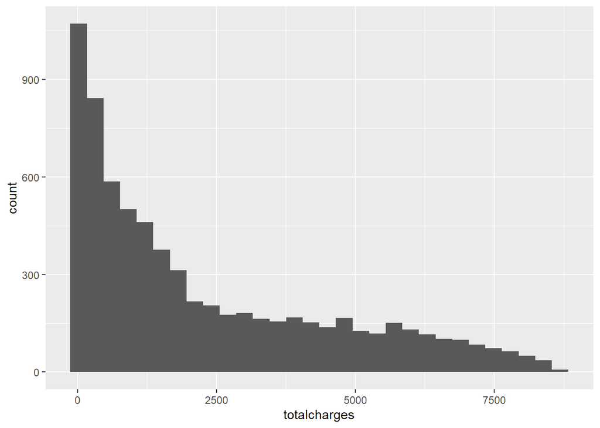

```r
ggplot(churn, aes(totalcharges)) +
  geom_histogram(bins = 30)
```

Los cargos totales presentan mayor frecuencia en valores bajos.

## Bar plot: churn proportion

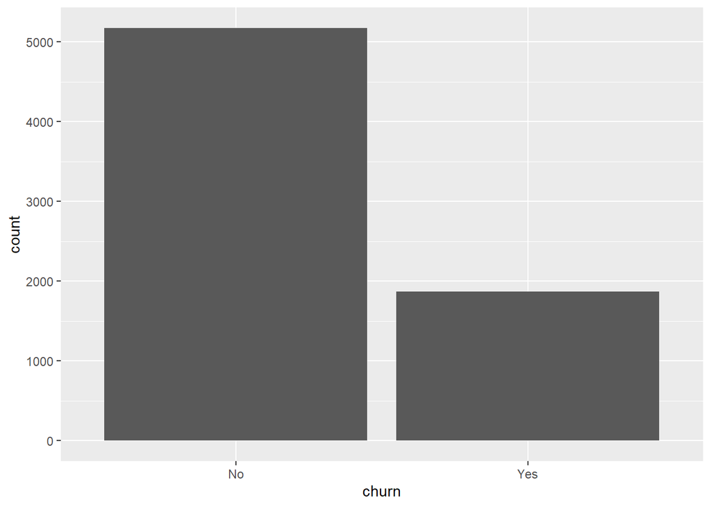

```r
ggplot(churn, aes(churn)) +
  geom_bar()
```

Hay más clientes que permanecen que clientes que cancelan.

## Boxplot: monthly charges vs churn

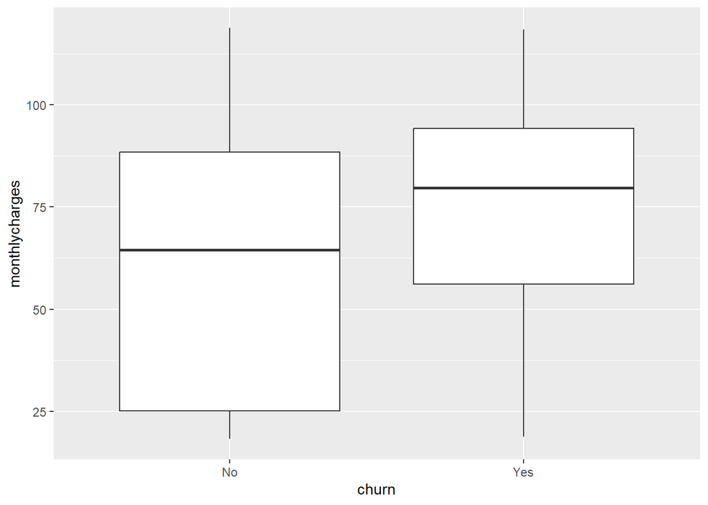

```r
ggplot(churn, aes(churn, monthlycharges)) +
  geom_boxplot()
```

Se observan diferencias en los cargos mensuales según cancelación.

## Density plot: monthly charges by churn

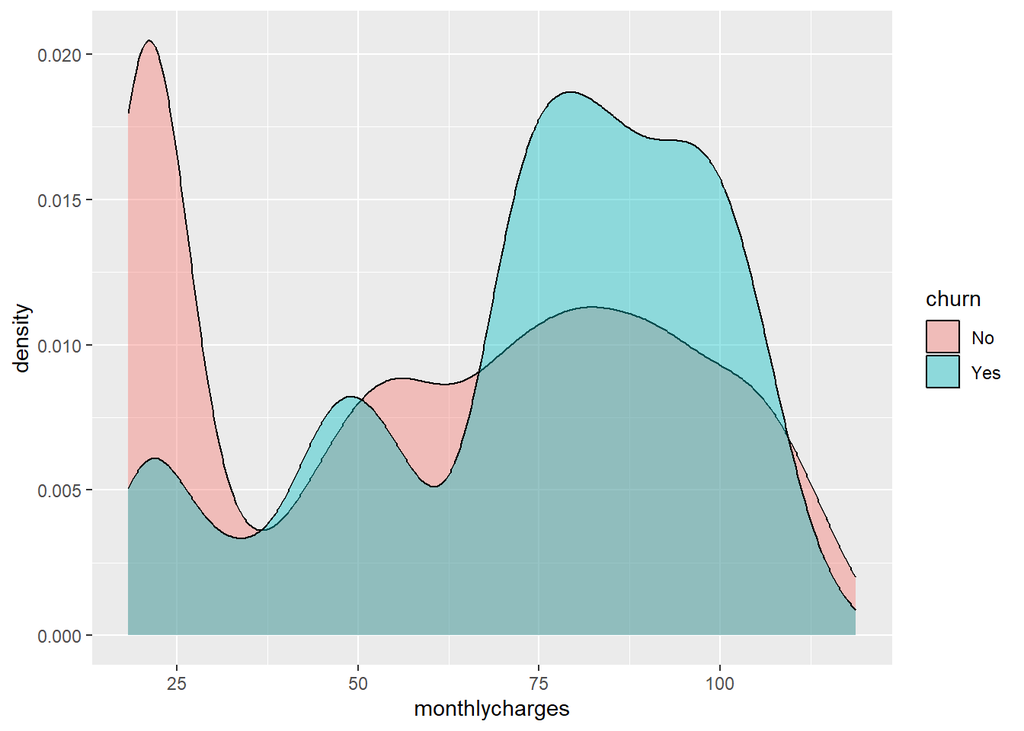

```r
ggplot(churn, aes(monthlycharges, fill = churn)) +
  geom_density(alpha = 0.4)
```

La distribución permite comparar ambos grupos.

## Churn by contract type

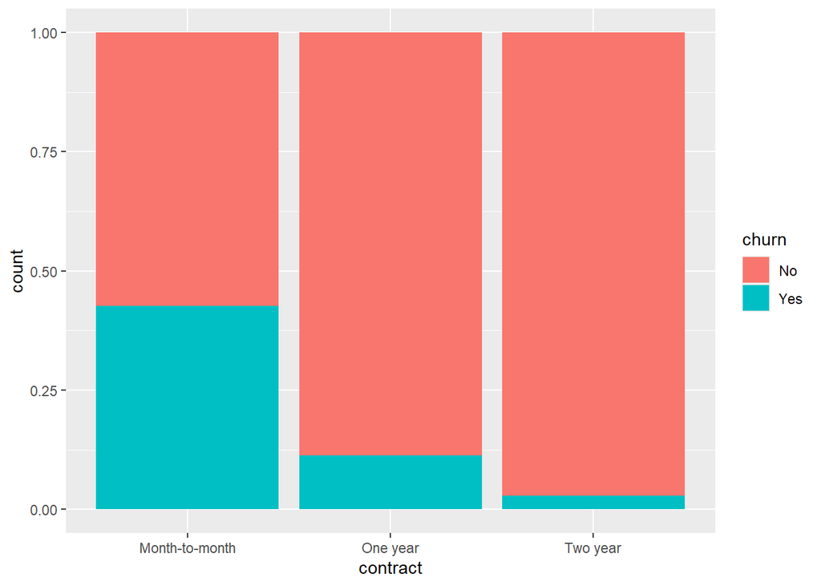

```r
ggplot(churn, aes(contract, fill = churn)) +
  geom_bar(position = "fill")
```

El contrato influye en la permanencia del cliente.

## Churn by internet service

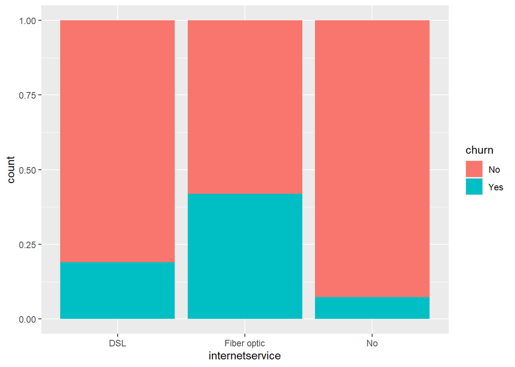

```r
ggplot(churn, aes(internetservice, fill = churn)) +
  geom_bar(position = "fill")
```

El servicio de internet muestra diferencias en cancelación.

## Charges vs tenure

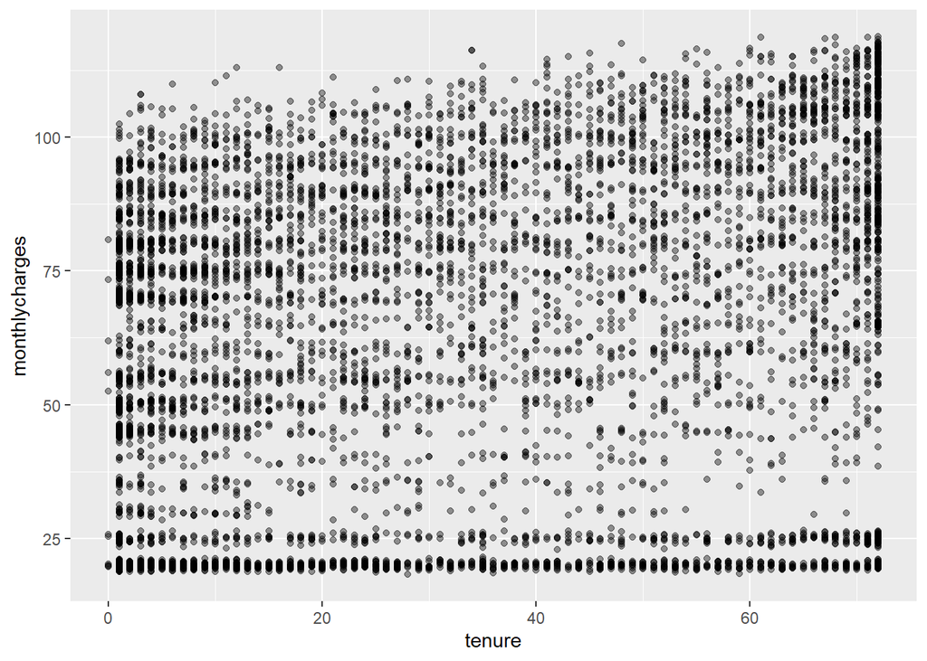

```r
ggplot(churn, aes(tenure, monthlycharges)) + geom_point(alpha = 0.4)
```

Se observa cómo cambian los cargos mensuales según el tiempo de permanencia.

## Charges vs tenure colored by churn

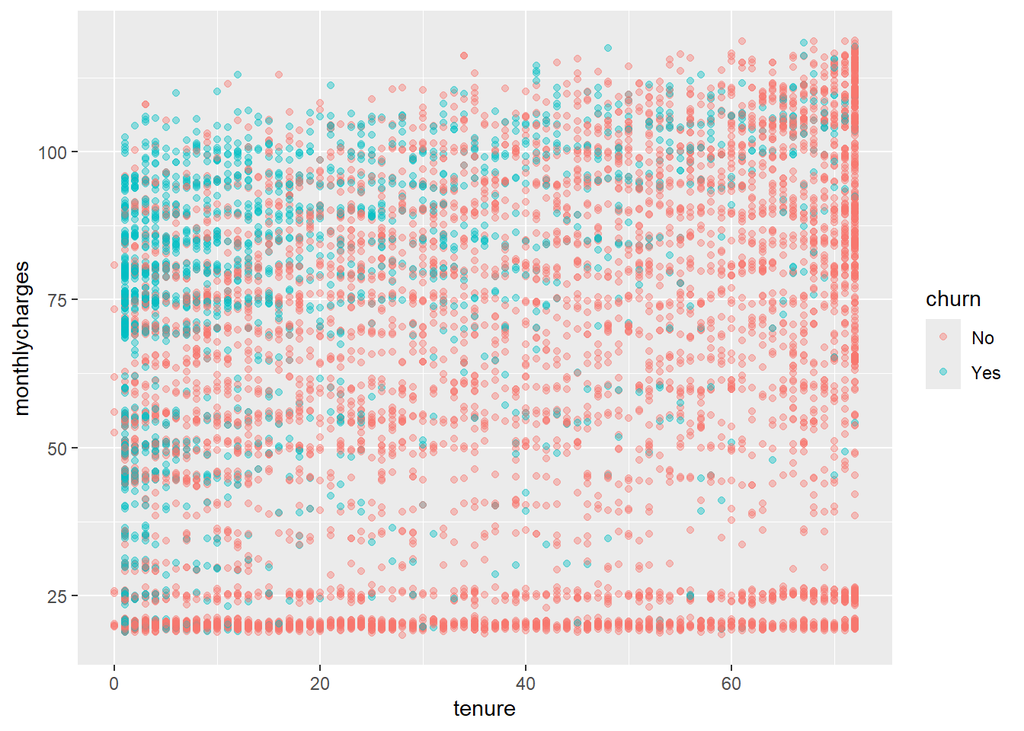

```r
ggplot(churn, aes(tenure, monthlycharges, color = churn)) + geom_point(alpha = 0.4)
```

Los clientes que cancelan y los que permanecen presentan comportamientos distintos.

## Add regression line

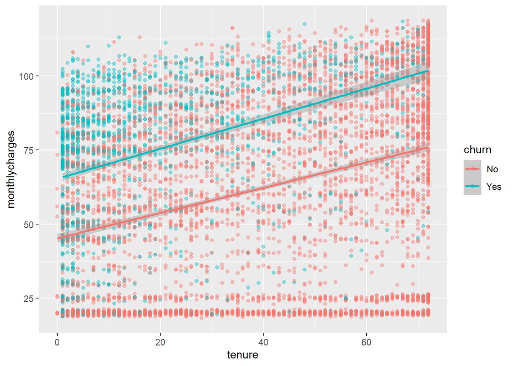

```r
ggplot(churn, aes(tenure, monthlycharges, color = churn)) + geom_point(alpha = 0.4) + geom_smooth(method = "lm")
```

## Facet by contract

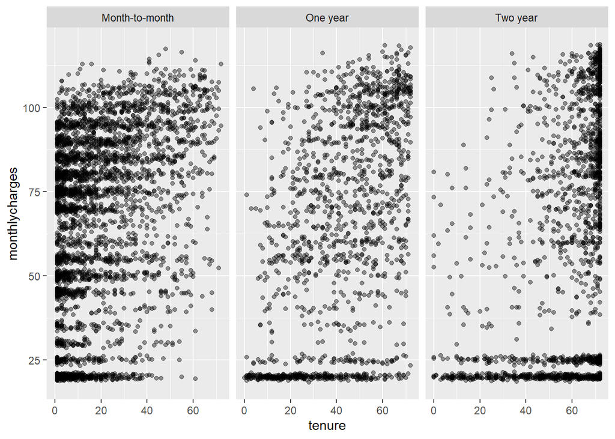

```r
ggplot(churn, aes(tenure, monthlycharges)) + geom_point(alpha = 0.4) + facet_wrap(~contract)
```

Cada tipo de contrato presenta una distribución diferente.

## Facet by internet service

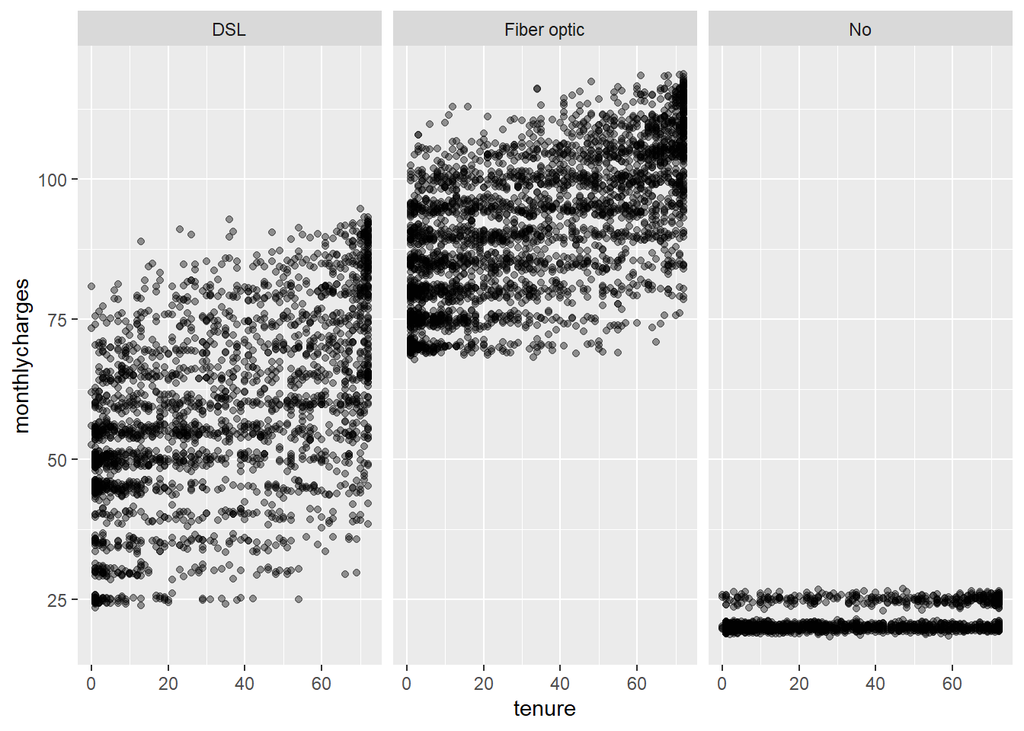

```r
ggplot(churn, aes(tenure, monthlycharges)) + geom_point(alpha = 0.4) + facet_wrap(~internetservice)
```

El servicio de internet también influye en el comportamiento de los datos.

## Bubble plot

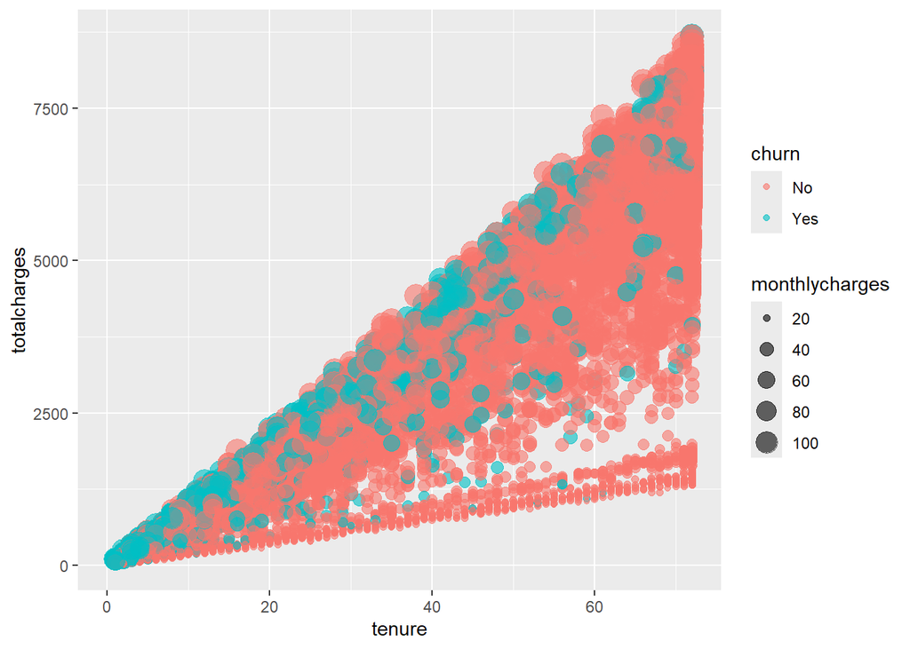

```r
ggplot(churn, aes(tenure, totalcharges, size = monthlycharges, color = churn)) + geom_point(alpha = 0.6)
```

El tamaño de los puntos permite comparar mejor los cargos mensuales.

## Publication-style plot

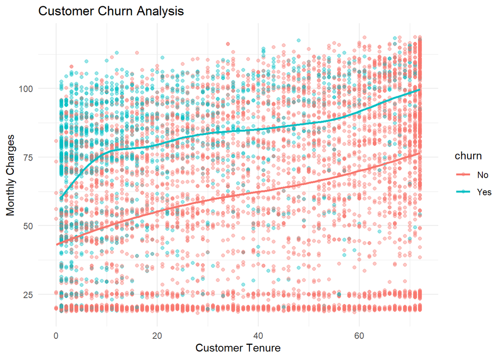

```r
ggplot(churn, aes(tenure, monthlycharges, color = churn)) + geom_point(alpha = 0.4) + geom_smooth(se = FALSE) + theme_minimal() + labs(title = "Customer Churn Analysis", x = "Customer Tenure", y = "Monthly Charges")
```

La gráfica resume de forma clara la relación entre permanencia y cargos.